# Long-term evaluation of the impact of urbanization on chloride levels in lakes in a temperate region

Sahana Kanabar

27/09/2020

## Introduction

This paper examined how urbanization has affected the salinity of watersheds in the Halifax region. These lakes face an increased risk of salinization as road salt applied in urban areas during the wintertime to improve road safety has been demonstrated to increase chloride concentrations in nearby water bodies. Increased salinity occurs when chloride contaminates the water through runoff. This can create toxic conditions that negatively impact freshwater aquatic organisms, prolong anoxic conditions, and degrade water quality. Water Quality Guidelines have been created by the Canadian Council of Ministers of the Environment that recommend that long-term chloride concentration not exceed 120 mg/L. This paper examined how changes in land use through urban development impact water salinity over time.

## Methods

The researchers examined 9 lakes in the Halifax region over a period of 35 years to quantify how urban development affect water salinity. Urban development, road vectors, and watershed boundaries were analyzed to ArcGIS to examine how each exposure of each lake to road salt changed over time. Water salinity was quantified through water quality sampling that was compiled from various sources.

## Results

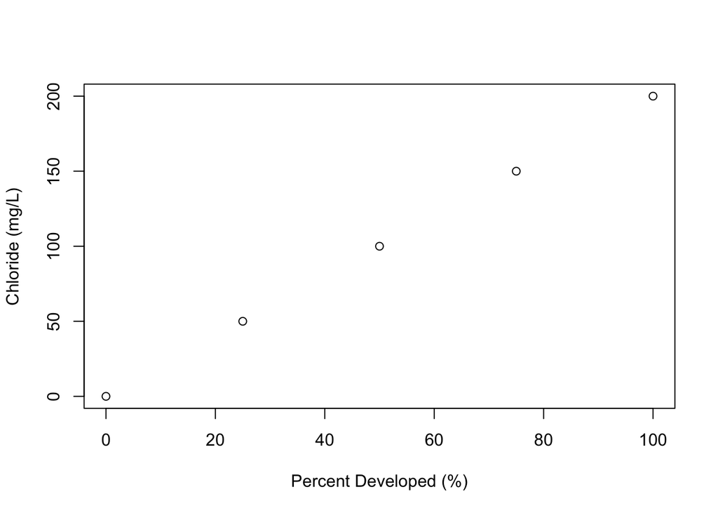

##### Figure 1. Relationship betwen urban development land use (%) and the chloride levels (mg/L) in nearby urban lakes

## Conclusion

Urban development was determined to pose a significant risk to urban lakes through increased water salinization. Samples from these urban lakes were regularly exceeding the Water Quality Guidelines of 120 mg/L, potentially posing risks to aquatic freshwater organisms.

#### Citation

Scott, R., Goulden, T., Letman, M., Hayward, J. and Jamieson, R., 2019. Long-term evaluation of the impact of urbanization on chloride levels in lakes in a temperate region. Journal of Environmental Management, 244, pp.285-293.

#### Github Link

https://github.com/skanabar27/assignment2